# Data Exploration Analysis

Joy Kung

2022-05-8

```r
library(vtable)
library(tidyverse)
library(jtools)
library(fixest)
library(readxl)
library(dplyr)
library(lubridate)
library(purrr)
```

```r
Clean_data <- read_csv("~/Desktop/Lab3_Rawdata/Clean_data.csv")
```

```
## ──────────────────────────────────────────────────────── Delimiter: "," chr
## (70): schname, keyword, monthorweek, INSTNM, CITY, STABBR, INSTURL, NPC... dbl
## (62): ...1, schid, keynum, index, unitid.x, opeid, N, opeid6, HCM2, PRE... lgl
## (1): after_release date (1): date
```

# About date cleaning

After combining the trend data table and scorecard data table, I create a new column called ‘index.s’ to compare index score with standardized index data (index-index mean)/sd of index. Since our research question focuses on predominantly bachelor’s degrees, so I only choose bachelor’s colleges data. I create a new date column by stringing the first week from ‘monthorweek’ column to leave the data level as a week per row per keyword. I use U.S. average salary with a bachelor’s degree from Smartasset (https://smartasset.com/retirement/the-average-salary-by-education-level#:~:text=The%20Average%20Salary%20With%20a%20Bachelor’s%20Degree,a%20bachelor’s%20degree%20is%202.3%25.) to determine the line between ‘high earning’ or ‘low earning’ college. The average salary over $67,860 is consider high earning. The article by Smartaset is published on April 06 2022 (so it’s relatively new) and the data is sourced from the Bureau of Labor Statistics (BLS). The college scorecard was released at September 2015, in order to determine if the release of scorecard shift students’ interests. I add a new column call ‘after_release’ to see if the row is from after September (after Sept 2015 = TRUE).

```r
Clean_data <- Clean_data %>% drop_na()
Clean_data <- rename(Clean_data, income_level = high_income)
regression_data <- select(Clean_data, schname, opeid, median_earnings, index.s, date, after_release, income_level)
show(regression_data)
```

```
## # A tibble: 986,089 × 7
##    schname   opeid median_earnings index.s date       after_release income_level
##    <chr>     <dbl> <chr>             <dbl> <date>     <lgl>         <chr>
##  1 young h… 160400 34100           -0.632  2013-03-31 FALSE         Low
##  2 young h… 160400 34100           -0.529  2013-04-07 FALSE         Low
##  3 young h… 160400 34100           -0.0648 2013-04-14 FALSE         Low
##  4 young h… 160400 34100           -0.0648 2013-04-21 FALSE         Low
##  5 young h… 160400 34100            2.77   2013-04-28 FALSE         Low
##  6 young h… 160400 34100           -0.219  2013-05-05 FALSE         Low
##  7 young h… 160400 34100           -0.426  2013-05-12 FALSE         Low
##  8 young h… 160400 34100           -0.426  2013-05-19 FALSE         Low
##  9 young h… 160400 34100           -0.683  2013-05-26 FALSE         Low
## 10 young h… 160400 34100           -0.322  2013-06-02 FALSE         Low
## # … with 986,079 more rows
```

I use drop_na() to drop rows containing missing value, and rename high_income column to income_level because it makes more sense. Since there are many columns in the data set that I won’t be using for regression and analysis even after data cleaning, I select some columns that are needed for my analysis, which are the new date, standard index(index.s), after_release and income_level.

#Regression method

Since we are trying to do a multivariate regression with two binary variables: time before and after the release of the scorecard (treatment), and the other which is control and treatment groups: low income and high income colleges. I think difference in differences regression model would work the best because it can control the time variable. I will also add the interaction in the regression to see if a college changes from low-income to high-income, what is the change in effect of the Scorecard on their indexes. The interaction term can also help to answer whether the scorecard shifted student interest towards high-earning colleges compared to low ones. *note: regression will show the standardize index number, which is indexes in relation to its mean.

#Summary table of mean index.s

```r
summarydata <- regression_data %>%
  group_by(after_release, income_level)%>%
  summarize(index= mean(index.s))
  show(summarydata)
```

```
## # A tibble: 4 × 3
## # Groups:   after_release [2]
##   after_release income_level   index
##   <lgl>         <chr>          <dbl>
## 1 FALSE         High          0.0497
## 2 FALSE         Low           0.0327
## 3 TRUE          High         -0.214
## 4 TRUE          Low          -0.141
```

Using summary table of mean index if both group before and after the treatment(group by after_release and income_level). This allows us to overall compare the means with two groups by only looking at the standard index. The result shows that for high earning college, mean index was roughly 0.049 before the scorecard released in 2015, and -0.21 after the release. For low earning college, mean index was 0.032 before the release and -0.14 after the release. This give us a brief idea/conclusion that indexes dropped after the release for both high/low earning groups.

#Regression

```r
regression1 <- lm(index.s ~ income_level*after_release
                  , data = regression_data)
export_summs(regression1, robust = TRUE, digits = 4)
```

|  | Model 1 |
| --- | --- |
| (Intercept) | 0.0497 *** |
|  | (0.0035) |
| income_levelLow | -0.0170 *** |
|  | (0.0037) |
| after_releaseTRUE | -0.2636 *** |
|  | (0.0083) |
| income_levelLow:after_releaseTRUE | 0.0898 *** |
|  | (0.0088) |
| N | 986089 |
| R2 | 0.0052 |
| Standard errors are heteroskedasticity robust. *** p < 0.001; ** p < 0.01; * p < 0.05. |  |

*note:low income level is considered the treated variable in this regression model. The intercept coefficient shows what the mean index would be if all other variables are 0, which means high-income colleges had a mean index of .0497 before the release of the scorecard. The income_levelLow coefficient shows that low-income colleges had a -.0170 lower index than the high-income colleges before the Scorecard. Since pursuing a higher education is considered as an investment for many people in a sense that earning a college degree will help us land on better jobs. It makes sense that higher income colleges tend to be more well-known and reputable, as result has more Google search times than lower income college before the release. The regression result corresponds with the summary table from the last part.

# Showing on the graph

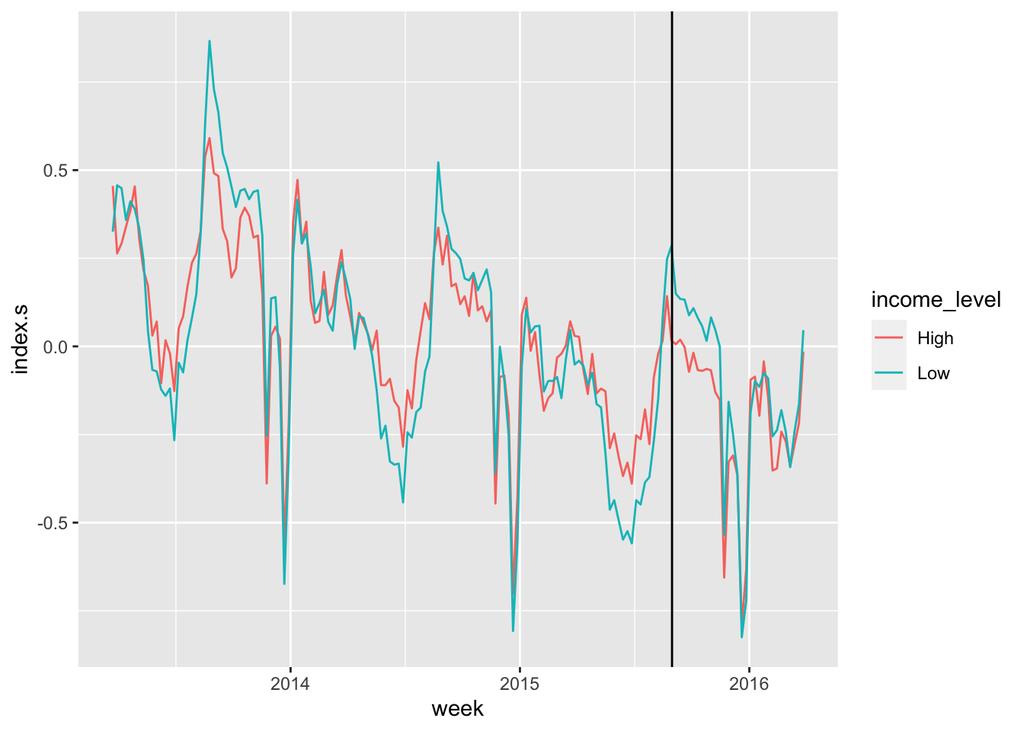

```r
regression_graph <- regression_data %>%
  group_by(income_level, week=floor_date(date, "week")) %>%
  summarize (index.s = mean(index.s))
ggplot(regression_graph, aes(x = week, y = index.s, color = income_level)) + geom_line() + geom_vline(xintercept = as.Date('2015-08-31'))
```

#Analysis of the graph 1. I grouped up the data by income level and week, for I want see a more precise trend of the indexes over time. Both low high earning and low earning college both follow a similar trend, and no group is consistently have higher indexes than another. Even after the scorecard was release (after vertical line) the indexes have no significant increase, conversely, the indexes slightly dropped after the release.

4, Reasoning and thoughts: We would think the release of scorecards would shift student interest in high-earning colleges, but there are many other factors that prospective students would want to consider when choosing a college. Factors like locations, majors, tuition, personal interest, etc, are also taken into consideration from my experience. Also, higher-earning college in the U.S.are usually more prestigious and competitive, and are private schools. Some students would choose to apply to schools that have higher acceptance rates and are more affordable possibly. On top of that, even within the same high-earning college, graduates from different majors will have different earnings based on their professionals. There are many other factors (endogenous variables) that affect students’ interest when searching for a college, and based on the data and regression here, I conclude that the release of scorecards doesn’t great big impact on students’ interest toward high-earning colleges.